# Uncontested House Races, 1946-2024

One name on the ballot, and the seventy years of House elections that made it ordinary

Democracy’s Data

Last updated September 13, 2026 at 10:53a EDT

Competitive elections are the mechanism by which voters control officeholders. That is the claim every civics class makes about the House: a member who serves badly can be voted out, so members behave. Mayhew argued that this single incentive, the perpetual pursuit of re-election, explains much of how Congress is organized.[^1] The claim assumes something it never states — that there is a contest to lose. So turn it into a question the record can answer: how often does an American voter actually get a choice for the House?

The answer, more often than most readers guess, is never. In 14.8% of the 17,403 district-elections held between 1946 and 2024, about one in seven, a single name sat in the box for *Representative in Congress*. Not a weak challenger who lost by forty points. Nobody at all, 2,568 times.

## The test

Using every House general election from 1946 through 2024, coded the same way throughout. The series is spliced from two sources. Gary Jacobson’s House elections dataset covers 1946–2014: one political scientist’s file, built and corrected across a career, and the standard dataset for studying congressional elections. The Clerk of the House’s *Statistics of the Presidential and Congressional Election*, the official returns Congress publishes about itself, extends it through 2024; every volume is downloadable from the Office of the House Historian (https://history.house.gov/Institution/Election-Statistics/Election-Statistics/).

This is the right source because the question is about change across seventy years, and answering it needs seventy years measured the same way. No agency maintains such a series; the Clerk’s volumes are authoritative and begin again each cycle. Jacobson’s file is one hand and one convention across decades, which is the shape the question needs, and the splice exists only because his file stops in 2014 and the question does not. The brief sits in the cluster the roster chapter leads, on the records Congress and its scholars keep about its own seats; this is the election-statistics half of that record.

## The data

The table is `races.csv`, one row per district in one election year, 17,403 rows. Each row carries `year`, `state`, and `stcd`, a state-district code, plus `south`, flagging the eleven former Confederate states. `dv` is the Democratic share of the **two-party vote** — Democratic votes divided by Democratic plus Republican votes, everyone else set aside; `incwin` says whether the sitting member, the **incumbent**, won; and `margin` is the winner’s distance from 50, so a winner with 62% of the two-party vote has a margin of 12. `uncontested` flags the races this brief is about, and `source` names which side of the splice the row came from. Here are four rows from 2014, two ordinary and two not:

| Year | State | District | South? | Dem % of two-party vote | Incumbent won | Uncontested | Margin from 50 |
| --- | --- | --- | --- | --- | --- | --- | --- |
| 2014 | 1 | 101 | 1 | 31.8 | 1 | FALSE | 18.2 |
| 2014 | 1 | 102 | 1 | 32.6 | 1 | FALSE | 17.4 |
| 2014 | 1 | 104 | 1 | NA | 1 | TRUE | NA |
| 2014 | 1 | 105 | 1 | NA | 1 | TRUE | NA |

Look at the vote-share column in the bottom two rows. **It is `NA` — missing, not zero and not 100.** When only one candidate runs there is no two-party share to compute, so the uncontested marker in this file is defined as exactly that: the vote share is missing. Jacobson’s file documents no uncontested flag anywhere; treating the missing share as one is a guess about a coding habit, well supported and still a guess. Anyone who opened the file and dropped the empty cells as bad rows would delete every race where competition failed completely, then report on how competitive American elections are. Here is what that does to the number. In 2024 the file holds 435 races, 38 of them with a single name on the ballot, so the uncontested share is 38 divided by 435, or 8.7%. Open the same file in a spreadsheet, delete the rows with a blank vote share as if they were errors, and 397 races remain, every one of them contested: the share is now zero, and the thing this brief measures has vanished from the file.

Two other decisions matter. The source file arrives padded: 14,777 of its 30,005 rows carry no year and no data, and they are dropped before anything is counted. And the vocabulary is fixed before the counting starts, because thresholds are choices and choices move answers:

| Term | Definition | Why this cut |
| --- | --- | --- |
| Uncontested | No two-party vote share exists — only one candidate ran | Not a choice; forced by the data |
| Competitive | Winner’s share within 5 points of 50% | A margin a normal swing could erase |
| Landslide | Winner’s share 20 or more points from 50% | A margin no campaign closes |

### The Clerk’s typeset record

After 2014 the only source is the Clerk’s volume, and it is a **document, not a dataset**. It is the one exception to this section’s governing fact that no federal agency counts votes: official congressional returns, district by district, for the whole country, in one free publication. But it is issued as a PDF typeset for a person holding a book, and eleven of them, 2004 through 2024, had to be turned into a table by a program reading the page. Here is the top of Alabama’s House results in the 2024 volume, as the text comes off the page:

```
                    FOR UNITED STATES REPRESENTATIVE
 1. Barry Moore, Republican  ....... 258,619
    Tom Holmes, Democrat  ....... 70,929
    Write-in  ....... 306

 2. Caroleene Dobson, Republican  ....... 131,414
    Shomari Figures, Democrat  ....... 158,041
    Write-in  ....... 219

 3. Mike Rogers, Republican  ....... 243,848
    Write-in  ....... 5,160
```

Notice what is not in it. There is no column called `district`; a district begins where a line begins with a number and a full stop, and the lines beneath belong to it because they are indented. There is no party column; the party is spelled out after the comma in each candidate’s name. The structure is a typesetting convention, so every property that makes the page readable to a person is a place the reading can go wrong. Here is the same state as a table:

| District | Democratic votes | Republican votes | Dem % of two-party vote | Uncontested |
| --- | --- | --- | --- | --- |
| 1 | 70,929 | 258,619 | 21.52 | no |
| 2 | 158,041 | 131,414 | 54.60 | no |
| 3 | 0 | 243,848 | — | yes |
| 4 | 0 | 274,498 | — | yes |
| 5 | 0 | 250,322 | — | yes |
| 6 | 102,504 | 243,741 | 29.60 | no |
| 7 | 186,723 | 106,312 | 63.72 | no |

Read the 3rd district’s row. No Democrat filed, so it carries 243,848 Republican votes, no Democratic votes, and a dash where the Democratic share of the two-party vote would go: with one party on the ballot there is no two-party vote to take a share of. That dash is the uncontested marker, in the Clerk’s volumes exactly as in Jacobson’s file.

Two reading hazards are worth meeting, because both produced wrong numbers before they were caught. The Clerk prints footnote references as raised numbers, which, once the page is reduced to plain text, land at the end of the line — exactly where the vote total belongs:

```
 5. Ralph Lee Abraham, Republican  ....... 2
                    134,616
    “Zach” Dasher, Republican  ....... 53,628
```

Read literally, that line says the winner received 2 votes rather than 134,616. The row looked fine: real candidate, real district, plausible state total. The correction applied to 24 rows across five volumes, and nothing in any aggregate would have shown it. The second hazard ran in the worse direction: Florida keeps unopposed candidates off the ballot entirely,[^2] and the volumes print a mark where their vote total would go. Those districts were dropped at first, which undercounted uncontested races — the very thing this brief exists to measure.

The table read from the volumes can be trusted only because there is a second file. Over 2004–2014 the two sources overlap on 2,260 districts, and they agree to a median of 0.03 points of vote share — in half the districts the two files differ by less than that. Every disagreement above a point was run down. Three were errors in the reading, since corrected; in two districts (Nebraska’s 3rd in 2004, Utah’s 1st in 2006) the official document disagrees with Jacobson in two separate places. Neither file was right; each was necessary to find what was wrong with the other. One thing is flagged rather than fixed: Louisiana’s November all-party ballot and December runoffs mix two elections into one printed row, so its rows carry a marker in `clerk_house.csv` and their shares are advisory.

> **Before you read on, commit to two lines.** The file flags the eleven former Confederate states, and the uncontested share will be computed separately for the South and for everywhere else. Write down which direction each of the two lines travels across the seventy years, and roughly where each starts.

## What it says about democracy

| Quantity | Value |
| --- | --- |
| Uncontested races, 1946 | 20.2% |
| Uncontested races, 2024 | 8.7% |
| Lowest share, and when | 6.2% in 1996 |
| Highest share, and when | 23.9% in 1950 |
| Uncontested races where the incumbent won | 2,221 of 2,568 |

The national series goes nowhere in particular: 20.2% in 1946, 8.7% in 2024. It swings from 6.2% to 21.8% between 1996 and 1998 alone, a two-year move wider than the whole seventy-year drift. That is a deflating answer, and it should be a suspicious one, because an average of one number per election tells you something only if the thing being averaged is one thing.

It is not one thing, in two ways. First, the races: 86.5% of uncontested races were won by a sitting member. Seats do not go uncontested because they are new or obscure; they go uncontested because somebody already holds them and the other party declined to field a candidate. Non-competition is a decision taken in a party office months before election day, not a verdict returned by voters. Second, the regions:

| Year | National (%) | South (%) | Rest of U.S. (%) |
| --- | --- | --- | --- |
| 1946 | 20.2 | 64.8 | 6.1 |
| 1958 | 23.2 | 79.2 | 5.2 |
| 1970 | 14.5 | 41.5 | 5.8 |
| 1982 | 13.1 | 28.4 | 7.5 |
| 1994 | 12.2 | 24.0 | 7.4 |
| 2006 | 13.6 | 19.8 | 10.9 |
| 2014 | 17.7 | 30.4 | 11.8 |

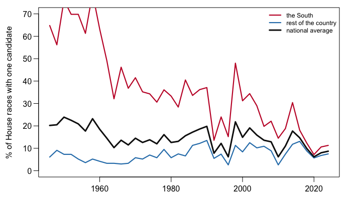

**Figure 1. The share of House races with one candidate, nationally and by region, 1946–2024.** Lines on a time axis, because the quantity is one share measured 40 times at even intervals and the finding is the shape: two lines travelling in opposite directions until they meet. In 1946 the South ran 64.8% of its House races unopposed against 6.1% everywhere else; by 2024 the two lines stand at 11.3% and 7.5%.

The South falls as the Voting Rights Act of 1965 — the federal law that put Black Southerners on the voter rolls — and the eventual arrival of Republican candidates dismantle a one-party system.[^3] The rest of the country rises, drifting toward one-party seats of its own. **Two countries converging — and the flat national average describes neither of them at any point along the way.** It is an average computed correctly from groups that are moving, faithfully reporting a middle position no part of the country occupied.

A challenger on the ballot is also a low bar, and the contested races have their own trend. Genuinely close races — a winner within five points of an even split — thinned from 20.7% of races in 1946 to 15.4% in 2024, touching 5.1% in 2004; landslides peaked at 36.3% in 1986. Figure 2 shows the whole distribution those thresholds were cut from.

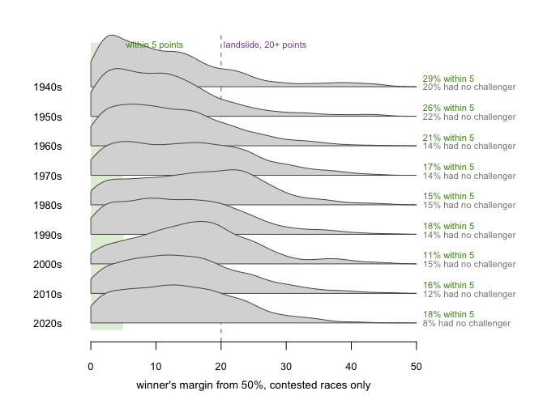

**Figure 2. The margin of victory in contested House races, by decade.** One curve per decade, showing where that decade’s margins pile up, drawn only from races that had a challenger, all scaled to the same height. The green band is the five-point definition of competitive, and the dashed line the twenty-point definition of a landslide. The share of contested races inside five points fell from 29% in the 1940s to 18% in the 2020s. The gray figures at the right count each decade’s races with no challenger at all, which appear in no curve.

The exceptions in that figure are worth telling. The thinnest near-tie zone belongs to the 2000s, at 11%, so the least competitive decade on this measure is not the most recent one. And the curves stay broad: every decade has races at every margin, which is exactly why a single cut point can be made to say almost anything.

## What this brief cannot tell you

**It cannot say why competition thinned outside the South.** The file has no district boundaries, no fundraising, and no candidate quality, so gerrymandering, geographic sorting and party recruitment cannot be told apart inside it. How much is maps and how much is where people chose to live is a live dispute this table cannot settle.

**It cannot say whether an uncontested seat is an unaccountable one.** In a safe seat the meaningful contest moves upstream into the primary, and primaries are real elections with real challengers. Whether they substitute adequately is disputed; nothing here measures them.

**It cannot certify its own central marker.** Uncontested is inferred from a missing vote share, not read from a documented flag, and the whole brief stands on that inference. The thresholds for competitive and landslide are conventions; different cuts move the levels, though the trends survive them. And a two-party share ignores third parties, which matters most in exactly the years when third parties mattered most.

## What you should have learned

- In 14.8% of 17,403 House district-elections since 1946, about one in seven, the voter had no choice at all; 86.5% of those races had a sitting member in them.
- The national uncontested share is nearly flat, 20.2% to 8.7%, and it is an average of two regions moving in opposite directions, from 64.8% and 6.1% apart in 1946 to nearly level today.
- Among races that were contested, the share within five points fell from 29% to 18% by decade, so the formal presence of a challenger overstates the choice on offer.
- The uncontested marker is encoded as a missing vote share; dropping missing values from this file deletes precisely the finding.
- The post-2014 series is read out of the Clerk’s typeset PDFs, and it is trustworthy only because 2,260 overlapping districts were checked against an independent file, catching bugs in both.

## Extensions

None of these is answered above, and every one can be answered from the tables the Sources section hands over.

- `by_year.csv` carries `pct_uncontested_south` and `pct_uncontested_non_south`. Plot both. When do the two lines meet, and what happened around then?
- `by_year.csv` also has `pct_competitive` and `pct_landslide` for every year. Follow them both. Which is the better one-line summary of what happened to House elections?
- `races.csv` flags each race as `uncontested`. Pick a recent year, group by `state`, and list the states with the most. Is an uncontested seat a safe seat, or a party that gave up?
- `clerk_house.csv` marks every Louisiana row with `la_primary`. Read a few of those rows and decide what you would publish for that state, and what you would be choosing to lose.
- **Stretch.** `pres_by_cd.csv` gives the presidential result inside each district. Join it to `races.csv` for one year and count the districts that voted one way for president and the other way for the House.
- **Stretch.** The Clerk will publish a 2026 volume after the next election. Download it, extend the series two years, and see whether the convergence in Figure 1 holds.

## Sources

**Data**

- Jacobson, G. C. House elections dataset, 1946–2014. Circulated privately among researchers; it has no public address, and obtaining it means asking.
- Office of the Clerk, U.S. House of Representatives, *Statistics of the Presidential and Congressional Election*, 2004–2024. Every volume is served by the Office of the House Historian at https://history.house.gov/Institution/Election-Statistics/Election-Statistics/; the Clerk’s own address for the series, https://clerk.house.gov/Votes/ElectionStatistics, no longer resolved when this was last checked.
- The Downballot (formerly Daily Kos Elections), presidential election results by congressional district, which no government calculates. https://www.the-downballot.com/p/the-downballots-calculations-of-presidential

**The data itself**

Every figure above is drawn from these tables. They are plain CSV, they open in a spreadsheet, and they are yours to take further.

`by_year.csv`, `clerk_house.csv`, `pres_by_cd.csv`, `races.csv`

**Academic literature**

- Mayhew, D. R. (1974). “Congressional Elections: The Case of the Vanishing Marginals.” *Polity* 6(3): 295–317.
- Mayhew, D. R. (1974). *Congress: The Electoral Connection.* Yale University Press. https://yalebooks.yale.edu/book/9780300105872/congress/

Why this data cannot be fetched again

```
Half the data behind this chapter comes from a source you cannot
download today, and no assistant can download it for you. The other half
refetches completely.

WHY NOT. The 1946-2014 spine is Gary Jacobson's House elections
dataset -- one row per race, with the two-party vote, incumbency,
and the district's presidential vote. It has never been published at
a URL. It circulates privately between researchers, the way academic
data did before repositories existed. Obtaining it means asking:
Professor Jacobson, or a colleague who has a copy.

WHAT EXISTS INSTEAD. The 2004-2024 extension is entirely public.
The Clerk of the House publishes official election statistics as
PDFs, keyless, at
https://clerk.house.gov/member_info/electionInfo/{year}/statistics{year}.pdf
for recent elections, with earlier years on the House history site's
Election Statistics pages; poppler's pdftotext turns them into
parseable text. District-level presidential results come from The
Downballot's presidential-by-district calculations, published as
freely exported Google Sheets. Those two sources let anyone rebuild
the recent decades and check them against the private spine where
they overlap.

WHAT YOU CAN STILL CHECK. If you obtain the Jacobson file, these
numbers say whether you are holding the same object:
- the file is 1,594,361 bytes: 30,005 rows, of which 14,777 are
  empty padding with no year at all; dropping them leaves 15,228
  real races -- 435 seats times 35 elections, plus a handful
- the combined race table, spine plus extension, runs to 17,403
  races
- the Clerk PDFs parse to 4,785 district result lines for 2004-2024,
  and the presidential-by-district file to 2,909 district lines
```

[^1]: David R. Mayhew, *Congress: The Electoral Connection* (New Haven: Yale University Press, 1974), https://yalebooks.yale.edu/book/9780300105872/congress/.
[^2]: Fla. Stat. § 101.151(7): the names of unopposed candidates do not appear on the general-election ballot. https://www.flsenate.gov/Laws/Statutes/2024/101.151.
[^3]: 52 U.S.C. § 10301 and following: https://www.law.cornell.edu/uscode/text/52/10301.